# CaseStudy-1

# Scenario

The director of marketing believes the company’s future success depends on maximizing the number of annual memberships. Therefore, your team wants to understand **how casual riders and annual members use Cyclistic bikes differently**. Your team will design a new marketing strategy to **convert casual riders into annual members** from these insights.

# ASK

## A clear statement of the business task

The financial analysts have concluded that annual membership is much more profitable than single-ride and full-day passes from their analysis. So to make people opt for the yearly membership, our marketing campaign should urge the casual riders to convert to annual riders. As a solution, we should understand why casual riders would convert to a yearly membership? Based on the insights from the above question, we can achieve the maximum required conversion rate from casual to annual riders.

# PREPARE

## Guiding questions

**1)Where is your data located?** Data is uploaded in RStudio cloud where I could use the R programming language for the analysis.

**3) Are there any issues with bias or credibility in this data? Does your data ROCCC?** The data has been collected directly from the company’s customers, that is, bike riders so there is no issue of bias and credibility for the same reason. It is also Reliable, Original, Comprehensive, Current, and Cited,, which satisfies ROCCC.

**4) How are you accessing licensing, privacy, security, and accessibility?** The data was collected by Motivate International Inc. under the following license https://www.divvybikes.com/data-license-agreement Also the dataset does not contain any personal information about its customers (or riders) to violate the privacy.

**5) How did you verify the data’s integrity?** The qualities required to verify the data integrity are accuracy, completeness, consistency, and trustworthiness. The data is complete as it contains all the required components to measure the entity. The data is consistent across the years with every year having its CSV file which is organized in an equal number of columns and same data types. As the credibility was proven before, it is also trustworthy.

**6) How does it help to answer your question?** By creating new features from existing ones like rideable_type, started_at, and ended_at(which are date-timestamp variables), we can deduce relationship between annual members and casual riders. The relationship analyzed will be useful to answer the question, that is, convert casual riders to annual members

**7) Are there any problems with the data?** Yes, the data had a couple of problems. There are few rows with ‘N/A’ values which needs to be removed. Also, there are duplicates which have to be eliminated.

# PROCESS

## Guiding questions

**2) Have you ensured your data’s integrity?** The qualities required to verify the data integrity are accuracy, completeness, consistency, and trustworthiness. The data is complete as it contains all the required components to measure the entity. The data is consistent across the years with every year having its CSV file which is organized in an equal number of columns and same data types. As the credibility was proven before, it is also trustworthy.

**3) What steps have you taken to ensure that your data is clean?** a) I have concatenated all the CSV files of each year into a single data frame b) Removed all the empty rows and columns from the concatenated data frame. c) Checked the unique values in each variable using **count()** so that there is no misspelling anywhere. d) Omitted **N/A** values from the entire data frame. e) Removed duplicates

**4) How can you verify that your data is clean and ready to analyze?** After performing all the cleaning tasks mentioned above, I ran the below functions to verify: a) Used filter() to check if there were any missing values b) Used count() to check the unique values of each variable c) Used duplicated() to check for any duplicates present.

**5) Have you documented your cleaning process so you can review and share those results?** Yes, please find the below comments and snippets for the documentation.

Let’s install and load all the required packages

```r
install.packages("tidyverse", repos = "http://cran.us.r-project.org")
install.packages("janitor", repos = "http://cran.us.r-project.org")
install.packages("scales", repos = "http://cran.us.r-project.org")
library("janitor")
library("tidyverse")
library(scales)
```

1)Concatenating all the CSVs into a single data frame. Let’s load all the individual CSVs and concatenate.

```r
df1 <- read_csv("~/Google-Data-Analytics-Certificate/CaseStudy-1/Dataset/202105-divvy-tripdata.csv")
df2 <- read_csv("~/Google-Data-Analytics-Certificate/CaseStudy-1/Dataset/202104-divvy-tripdata.csv")
df3 <- read_csv("~/Google-Data-Analytics-Certificate/CaseStudy-1/Dataset/202103-divvy-tripdata.csv")
df4 <- read_csv("~/Google-Data-Analytics-Certificate/CaseStudy-1/Dataset/202102-divvy-tripdata.csv")
df5<- read_csv("~/Google-Data-Analytics-Certificate/CaseStudy-1/Dataset/202101-divvy-tripdata.csv")
df6 <- read_csv("~/Google-Data-Analytics-Certificate/CaseStudy-1/Dataset/202012-divvy-tripdata.csv")
df7 <- read_csv("~/Google-Data-Analytics-Certificate/CaseStudy-1/Dataset/202011-divvy-tripdata.csv")
df8 <- read_csv("~/Google-Data-Analytics-Certificate/CaseStudy-1/Dataset/202010-divvy-tripdata.csv")
df9 <- read_csv("~/Google-Data-Analytics-Certificate/CaseStudy-1/Dataset/202009-divvy-tripdata.csv")
df10 <- read_csv("~/Google-Data-Analytics-Certificate/CaseStudy-1/Dataset/202008-divvy-tripdata.csv")
df11 <- read_csv("~/Google-Data-Analytics-Certificate/CaseStudy-1/Dataset/202007-divvy-tripdata.csv")
df12 <- read_csv("~/Google-Data-Analytics-Certificate/CaseStudy-1/Dataset/202006-divvy-tripdata.csv")
binded_df <- rbind(df1, df2, df3, df4, df5, df6, df7, df8, df9, df10, df11, df12)
```

2)Removing any empty rows or columns present and checking for missing values (Check the missing values for each variable)

```r
new_binded_df <- remove_empty(binded_df, which=c("rows", "cols"))
count(filter(new_binded_df, start_station_name==''),start_station_name, member_casual,sort=TRUE)
```

```
## # A tibble: 0 x 3
## # ... with 3 variables: start_station_name <chr>, member_casual <chr>, n <int>
```

3)count() returns unique values of the variable passed

```r
binded_df %>%
  count(rideable_type)
```

```
## # A tibble: 3 x 2
##   rideable_type       n
##   <chr>           <int>
## 1 classic_bike   843585
## 2 docked_bike   2341486
## 3 electric_bike  888490
```

4)omitting NA values in the entire data frame

```r
new_binded_df <- na.omit(binded_df)
```

5)Removing duplicates

```r
new_binded_df_no_dups <- new_binded_df[!duplicated(new_binded_df$ride_id), ]
```

# Analyze

## Guiding Questions

Also I created new features using the existing ones. Check them below:

**a) riding_time**

```r
clean_df <- new_binded_df_no_dups
clean_df <- clean_df %>%
  mutate(riding_time = as.numeric(ended_at-started_at)/60)
clean_df
```

```
## # A tibble: 3,759,054 x 14
##    ride_id          rideable_type started_at          ended_at
##    <chr>            <chr>         <dttm>              <dttm>
##  1 0F3AE375DEC608D9 classic_bike  2021-05-02 08:21:19 2021-05-02 09:20:46
##  2 43E916C72D4C77B3 electric_bike 2021-05-01 22:15:55 2021-05-01 22:51:27
##  3 2AAB47362E76AC7F electric_bike 2021-05-31 00:50:15 2021-05-31 00:56:59
##  4 344011882FBBB8BD classic_bike  2021-05-31 07:35:08 2021-05-31 08:33:45
##  5 238E58CAB07FA2A8 electric_bike 2021-05-02 16:55:59 2021-05-02 16:57:10
##  6 BF99592737266B31 classic_bike  2021-05-07 06:03:21 2021-05-07 07:12:20
##  7 059C6EFD3DA52B3C classic_bike  2021-05-19 18:04:07 2021-05-19 18:51:41
##  8 F1FDE9F333E8A72F classic_bike  2021-05-30 16:41:27 2021-05-30 16:56:02
##  9 13576FA2EB822C12 classic_bike  2021-05-24 17:59:36 2021-05-24 18:01:07
## 10 033FBC7213DC960B classic_bike  2021-05-24 18:04:28 2021-05-24 18:36:39
## # ... with 3,759,044 more rows, and 10 more variables:
## #   start_station_name <chr>, start_station_id <chr>, end_station_name <chr>,
## #   end_station_id <chr>, start_lat <dbl>, start_lng <dbl>, end_lat <dbl>,
## #   end_lng <dbl>, member_casual <chr>, riding_time <dbl>
```

**b) year_month**

```r
clean_df <- clean_df %>%
  mutate(year_month=paste(strftime(clean_df$started_at, "%Y"), "-",
                          strftime(clean_df$started_at, "%m"), "-",
                          strftime(clean_df$started_at, "%b")))
clean_df
```

```
## # A tibble: 3,759,054 x 15
##    ride_id          rideable_type started_at          ended_at
##    <chr>            <chr>         <dttm>              <dttm>
##  1 0F3AE375DEC608D9 classic_bike  2021-05-02 08:21:19 2021-05-02 09:20:46
##  2 43E916C72D4C77B3 electric_bike 2021-05-01 22:15:55 2021-05-01 22:51:27
##  3 2AAB47362E76AC7F electric_bike 2021-05-31 00:50:15 2021-05-31 00:56:59
##  4 344011882FBBB8BD classic_bike  2021-05-31 07:35:08 2021-05-31 08:33:45
##  5 238E58CAB07FA2A8 electric_bike 2021-05-02 16:55:59 2021-05-02 16:57:10
##  6 BF99592737266B31 classic_bike  2021-05-07 06:03:21 2021-05-07 07:12:20
##  7 059C6EFD3DA52B3C classic_bike  2021-05-19 18:04:07 2021-05-19 18:51:41
##  8 F1FDE9F333E8A72F classic_bike  2021-05-30 16:41:27 2021-05-30 16:56:02
##  9 13576FA2EB822C12 classic_bike  2021-05-24 17:59:36 2021-05-24 18:01:07
## 10 033FBC7213DC960B classic_bike  2021-05-24 18:04:28 2021-05-24 18:36:39
## # ... with 3,759,044 more rows, and 11 more variables:
## #   start_station_name <chr>, start_station_id <chr>, end_station_name <chr>,
## #   end_station_id <chr>, start_lat <dbl>, start_lng <dbl>, end_lat <dbl>,
## #   end_lng <dbl>, member_casual <chr>, riding_time <dbl>, year_month <chr>
```

```r
clean_df <- filter(clean_df, year_month!="2021 - 06 (Jun)")
clean_df
```

```
## # A tibble: 3,759,054 x 15
##    ride_id          rideable_type started_at          ended_at
##    <chr>            <chr>         <dttm>              <dttm>
##  1 0F3AE375DEC608D9 classic_bike  2021-05-02 08:21:19 2021-05-02 09:20:46
##  2 43E916C72D4C77B3 electric_bike 2021-05-01 22:15:55 2021-05-01 22:51:27
##  3 2AAB47362E76AC7F electric_bike 2021-05-31 00:50:15 2021-05-31 00:56:59
##  4 344011882FBBB8BD classic_bike  2021-05-31 07:35:08 2021-05-31 08:33:45
##  5 238E58CAB07FA2A8 electric_bike 2021-05-02 16:55:59 2021-05-02 16:57:10
##  6 BF99592737266B31 classic_bike  2021-05-07 06:03:21 2021-05-07 07:12:20
##  7 059C6EFD3DA52B3C classic_bike  2021-05-19 18:04:07 2021-05-19 18:51:41
##  8 F1FDE9F333E8A72F classic_bike  2021-05-30 16:41:27 2021-05-30 16:56:02
##  9 13576FA2EB822C12 classic_bike  2021-05-24 17:59:36 2021-05-24 18:01:07
## 10 033FBC7213DC960B classic_bike  2021-05-24 18:04:28 2021-05-24 18:36:39
## # ... with 3,759,044 more rows, and 11 more variables:
## #   start_station_name <chr>, start_station_id <chr>, end_station_name <chr>,
## #   end_station_id <chr>, start_lat <dbl>, start_lng <dbl>, end_lat <dbl>,
## #   end_lng <dbl>, member_casual <chr>, riding_time <dbl>, year_month <chr>
```

**c) Weekday**

```r
clean_df <- clean_df %>%
  mutate(weekday=strftime(clean_df$ended_at, "%a"))
clean_df
```

```
## # A tibble: 3,759,054 x 16
##    ride_id          rideable_type started_at          ended_at
##    <chr>            <chr>         <dttm>              <dttm>
##  1 0F3AE375DEC608D9 classic_bike  2021-05-02 08:21:19 2021-05-02 09:20:46
##  2 43E916C72D4C77B3 electric_bike 2021-05-01 22:15:55 2021-05-01 22:51:27
##  3 2AAB47362E76AC7F electric_bike 2021-05-31 00:50:15 2021-05-31 00:56:59
##  4 344011882FBBB8BD classic_bike  2021-05-31 07:35:08 2021-05-31 08:33:45
##  5 238E58CAB07FA2A8 electric_bike 2021-05-02 16:55:59 2021-05-02 16:57:10
##  6 BF99592737266B31 classic_bike  2021-05-07 06:03:21 2021-05-07 07:12:20
##  7 059C6EFD3DA52B3C classic_bike  2021-05-19 18:04:07 2021-05-19 18:51:41
##  8 F1FDE9F333E8A72F classic_bike  2021-05-30 16:41:27 2021-05-30 16:56:02
##  9 13576FA2EB822C12 classic_bike  2021-05-24 17:59:36 2021-05-24 18:01:07
## 10 033FBC7213DC960B classic_bike  2021-05-24 18:04:28 2021-05-24 18:36:39
## # ... with 3,759,044 more rows, and 12 more variables:
## #   start_station_name <chr>, start_station_id <chr>, end_station_name <chr>,
## #   end_station_id <chr>, start_lat <dbl>, start_lng <dbl>, end_lat <dbl>,
## #   end_lng <dbl>, member_casual <chr>, riding_time <dbl>, year_month <chr>,
## #   weekday <chr>
```

**d) start_hour**

```r
clean_df <- clean_df %>%
  mutate(start_hour=strftime(clean_df$ended_at, format = "%H",tz = "UTC"))
clean_df
```

```
## # A tibble: 3,759,054 x 17
##    ride_id          rideable_type started_at          ended_at
##    <chr>            <chr>         <dttm>              <dttm>
##  1 0F3AE375DEC608D9 classic_bike  2021-05-02 08:21:19 2021-05-02 09:20:46
##  2 43E916C72D4C77B3 electric_bike 2021-05-01 22:15:55 2021-05-01 22:51:27
##  3 2AAB47362E76AC7F electric_bike 2021-05-31 00:50:15 2021-05-31 00:56:59
##  4 344011882FBBB8BD classic_bike  2021-05-31 07:35:08 2021-05-31 08:33:45
##  5 238E58CAB07FA2A8 electric_bike 2021-05-02 16:55:59 2021-05-02 16:57:10
##  6 BF99592737266B31 classic_bike  2021-05-07 06:03:21 2021-05-07 07:12:20
##  7 059C6EFD3DA52B3C classic_bike  2021-05-19 18:04:07 2021-05-19 18:51:41
##  8 F1FDE9F333E8A72F classic_bike  2021-05-30 16:41:27 2021-05-30 16:56:02
##  9 13576FA2EB822C12 classic_bike  2021-05-24 17:59:36 2021-05-24 18:01:07
## 10 033FBC7213DC960B classic_bike  2021-05-24 18:04:28 2021-05-24 18:36:39
## # ... with 3,759,044 more rows, and 13 more variables:
## #   start_station_name <chr>, start_station_id <chr>, end_station_name <chr>,
## #   end_station_id <chr>, start_lat <dbl>, start_lng <dbl>, end_lat <dbl>,
## #   end_lng <dbl>, member_casual <chr>, riding_time <dbl>, year_month <chr>,
## #   weekday <chr>, start_hour <chr>
```

**2) Has your data been properly formatted?** Yes, the data has been properly formatted with respective to their values.

**3) What surprises did you discover in the data?** Surprisingly, I found many NA values in the information about station names and ids (combined). Maybe while collecting the data, customers were not sure about the station’s id numbers. However, the NA values in these fields will not affect our analysis.

**4) What trends or relationships did you find in the data?** Let’s compare the member_casual feature with other newly created features to find any trends:

**a) Let’s start by comparing the number of members and casual riders**

```r
df <- clean_df
df %>%
  group_by(member_casual) %>%
  summarize(count=length(ride_id),
            percentage_of_total=(length(ride_id)/nrow(df))*100)
```

```
## # A tibble: 2 x 3
##   member_casual   count percentage_of_total
##   <chr>           <int>               <dbl>
## 1 casual        1578112                42.0
## 2 member        2180942                58.0
```

From above, it is known that 58% of the total riders in the last 12 months were annual members. The remaining(42%) are casual riders.

Let’s plot the above table.

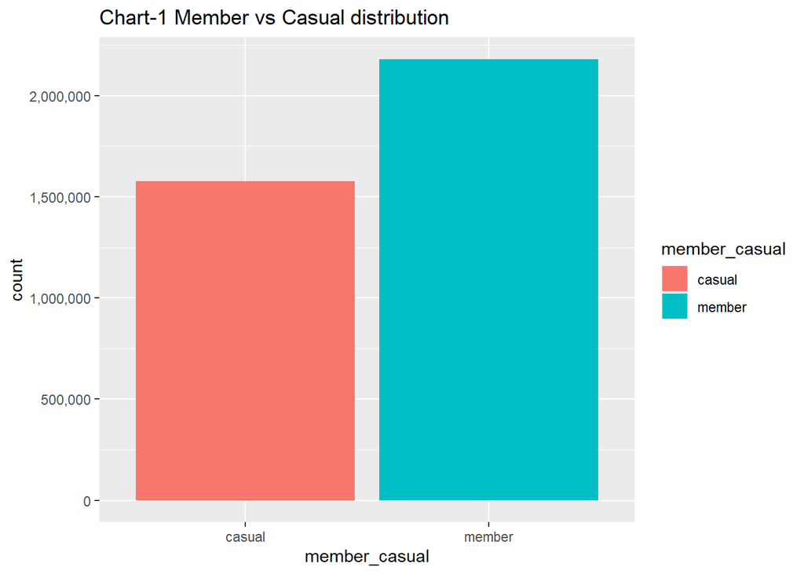

```r
ggplot(df, aes(member_casual, fill=member_casual))+
  geom_bar()+
  labs(title="Chart-1 Member vs Casual distribution")+
  scale_y_continuous(labels=comma)
```

**b) Let’s check what percent of annual and casual riders ride every month**

```r
df %>%
  group_by(year_month) %>%
  summarize(count=length(ride_id),
            percentage_of_total=(length(ride_id)/nrow(df))*100,
            members_count=sum(member_casual=="member"),
            members_percent=(sum(member_casual=="member")/length(ride_id))*100,
            casual_count=sum(member_casual=="casual"),
            casual_percent=(sum(member_casual=="casual")/length(ride_id))*100) %>%
  arrange(year_month)
```

```
## # A tibble: 13 x 7
##    year_month       count percentage_of_t~ members_count members_percent casual_count
##    <chr>            <int>            <dbl>         <int>           <dbl>        <int>
##  1 2020 - 06 - Jun 338163           9.00          185869            55.0       152294
##  2 2020 - 07 - Jul 548013          14.6           281020            51.3       266993
##  3 2020 - 08 - Aug 611231          16.3           326042            53.3       285189
##  4 2020 - 09 - Sep 501353          13.3           285382            56.9       215971
##  5 2020 - 10 - Oct 340912           9.07          217622            63.8       123290
##  6 2020 - 11 - Nov 223524           5.95          149987            67.1        73537
##  7 2020 - 12 - Dec 114199           3.04           89624            78.5        24575
##  8 2021 - 01 - Jan  83696           2.23           68958            82.4        14738
##  9 2021 - 02 - Feb  42745           1.14           34212            80.0         8533
## 10 2021 - 03 - Mar 205002           5.45          129511            63.2        75491
## 11 2021 - 04 - Apr 296741           7.89          177137            59.7       119604
## 12 2021 - 05 - May 450445          12.0           234383            52.0       216062
## 13 2021 - 06 - Jun   3030           0.0806          1195            39.4         1835
## # ... with 1 more variable: casual_percent <dbl>
```

Let’s plot the above table.

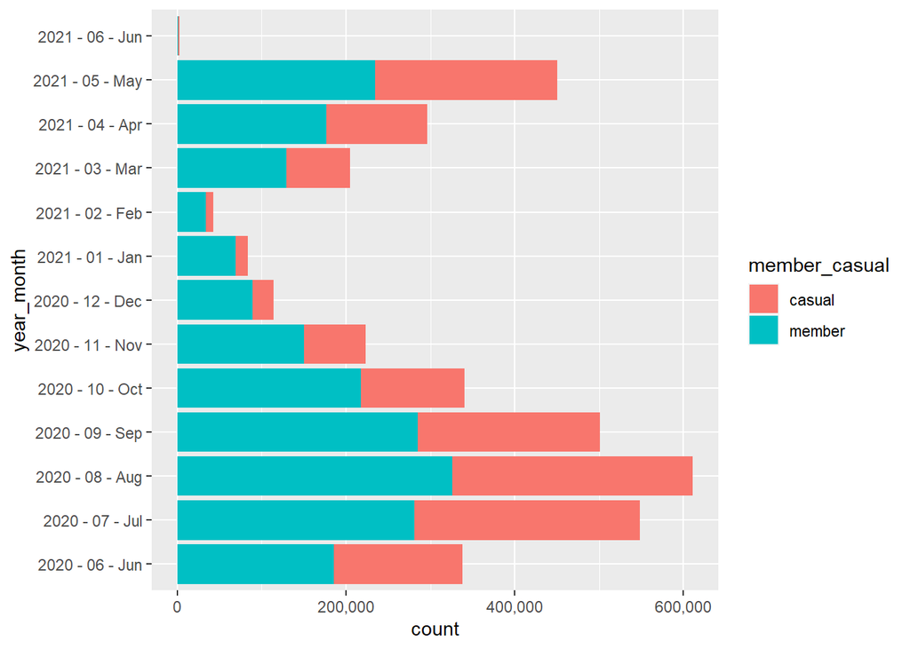

```r
ggplot(df, aes(year_month, fill=member_casual))+
  geom_bar()+
  coord_flip()+
  scale_y_continuous(labels=comma)
```

**c) Let’s now check how riders ride in each hour of the day. Also, later we’ll check how this varies per each day of the week**

```r
start_hour_df <- df %>%
  group_by(start_hour) %>%
  summarize(count=length(ride_id),
            percentage_of_total=(length(ride_id)/nrow(df))*100,
            members_count=sum(member_casual=="member"),
            members_percent=(sum(member_casual=="member")/length(ride_id))*100,
            casual_count=sum(member_casual=="casual"),
            casual_percent=(sum(member_casual=="casual")/length(ride_id))*100) %>%
  arrange(start_hour)
start_hour_df
```

```
## # A tibble: 24 x 7
##    start_hour  count percentage_of_t~ members_count members_percent casual_count
##    <chr>       <int>            <dbl>         <int>           <dbl>        <int>
##  1 00          48190            1.28          15927            33.1        32263
##  2 01          31594            0.840          9204            29.1        22390
##  3 02          18003            0.479          4688            26.0        13315
##  4 03          10094            0.269          2602            25.8         7492
##  5 04           8029            0.214          3290            41.0         4739
##  6 05          19738            0.525         14985            75.9         4753
##  7 06          61466            1.64          50183            81.6        11283
##  8 07         115622            3.08          94841            82.0        20781
##  9 08         145835            3.88         114625            78.6        31210
## 10 09         132874            3.53          95486            71.9        37388
## # ... with 14 more rows, and 1 more variable: casual_percent <dbl>
```

Let’s plot the above table.

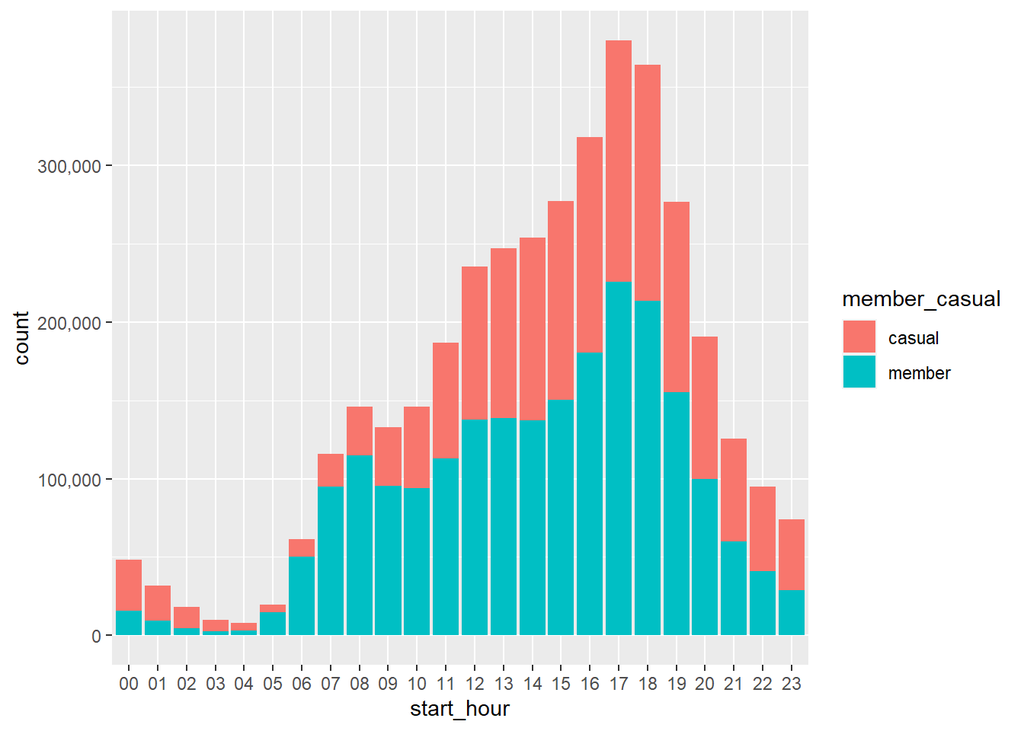

```r
ggplot(df, aes(start_hour, fill=member_casual))+
  geom_bar()+
  scale_y_continuous(labels=comma)
```

Now let’s plot the same comparison for each day of the week.

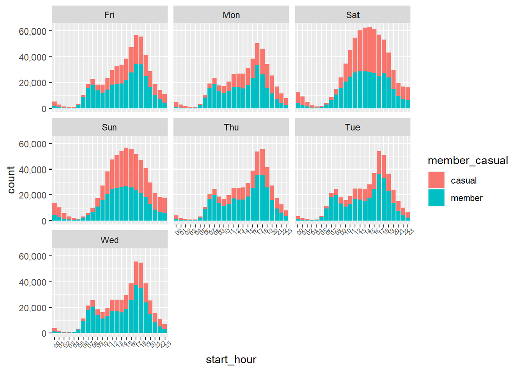

```r
ggplot(df, aes(start_hour, fill=member_casual))+
  geom_bar()+
  facet_wrap(~weekday)+
  scale_y_continuous(labels=comma)+
  theme(axis.text.x = element_text(size=6, angle=45))
```

We can see that the number of casual riders is more on the weekends than on weekdays (where annual members are more).

To more comprehend the above analysis, let’s divide the hours into morning, afternoon, and evening

```r
df <- mutate(df, hour_of_the_day=ifelse(df$start_hour<12, "Morning",
                                        ifelse(df$start_hour>=12 & df$start_hour<19, "Afternoon", "Evening")))
```

```r
hour_type_df <- df %>%
  group_by(hour_of_the_day) %>%
  summarize(count=length(ride_id),
            percentage_of_total=(length(ride_id)/nrow(df))*100,
            members_count=sum(member_casual=="member"),
            members_percent=(sum(member_casual=="member")/length(ride_id))*100,
            casual_count=sum(member_casual=="casual"),
            casual_percent=(sum(member_casual=="casual")/length(ride_id))*100)
hour_type_df
```

```
## # A tibble: 3 x 7
##   hour_of_the_day   count percentage_of_total members_count members_percent
##   <chr>             <int>               <dbl>         <int>           <dbl>
## 1 Afternoon       2073602                55.2       1183566            57.1
## 2 Evening          761506                20.3        384970            50.6
## 3 Morning          923946                24.6        612406            66.3
## # ... with 2 more variables: casual_count <int>, casual_percent <dbl>
```

Let’s plot the above table

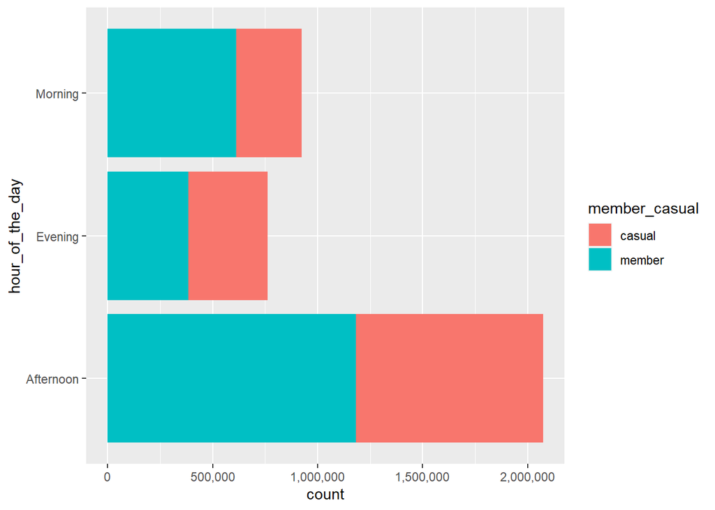

```r
ggplot(df, aes(hour_of_the_day, fill=member_casual))+
  geom_bar()+
  #facet_wrap(~hour_of_the_day, scales = "free")+
  scale_y_continuous(labels=comma)+
  coord_flip()
```

**d) Let’s check how number of riders vary per each week of the day**

```r
df %>%
  group_by(weekday) %>%
  summarize(count=length(ride_id),
            percentage_of_total=(length(ride_id)/nrow(df))*100,
            members_count=sum(member_casual=="member"),
            members_percent=(sum(member_casual=="member")/length(ride_id))*100,
            casual_count=sum(member_casual=="casual"),
            casual_percent=(sum(member_casual=="casual")/length(ride_id))*100)
```

```
## # A tibble: 7 x 7
##   weekday  count percentage_of_total members_count members_percent casual_count
##   <chr>    <int>               <dbl>         <int>           <dbl>        <int>
## 1 Fri     536266                14.3        326508            60.9       209758
## 2 Mon     466091                12.4        277061            59.4       189030
## 3 Sat     702128                18.7        346588            49.4       355540
## 4 Sun     632382                16.8        298854            47.3       333528
## 5 Thu     485232                12.9        315749            65.1       169483
## 6 Tue     458813                12.2        300638            65.5       158175
## 7 Wed     478142                12.7        315544            66.0       162598
## # ... with 1 more variable: casual_percent <dbl>
```

Saturdays and Sundays had more casual riders than annual members. Members usually ride on the weekdays due to work.

Let’s plot the above table.

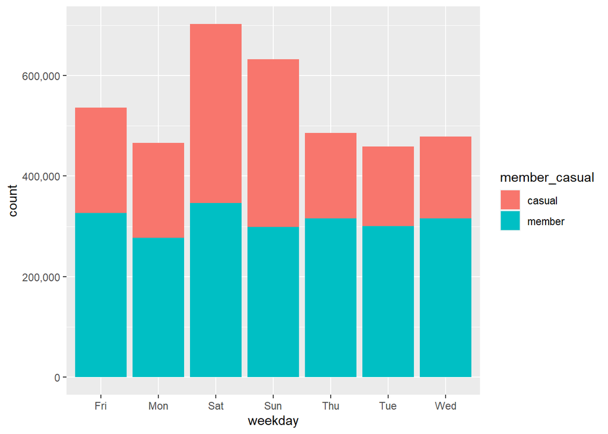

```r
ggplot(df, aes(weekday, fill=member_casual))+
  geom_bar()+
  scale_y_continuous(labels=comma)
```

**e) Let’s check what types of bikes do riders usually ride**

```r
df %>%
  group_by(rideable_type) %>%
  summarize(count=length(ride_id),
            percentage_of_total=(length(ride_id)/nrow(df))*100,
            members_count=sum(member_casual=="member"),
            members_percent=(sum(member_casual=="member")/length(ride_id))*100,
            casual_count=sum(member_casual=="casual"),
            casual_percent=(sum(member_casual=="casual")/length(ride_id))*100)
```

```
## # A tibble: 3 x 7
##   rideable_type   count percentage_of_total members_count members_percent
##   <chr>           <int>               <dbl>         <int>           <dbl>
## 1 classic_bike   841072                22.4        576669            68.6
## 2 docked_bike   2337520                62.2       1265213            54.1
## 3 electric_bike  580462                15.4        339060            58.4
## # ... with 2 more variables: casual_count <int>, casual_percent <dbl>
```

It seems docked bikes are more preferred over classic and electric bikes. However, riders have also chosen classic and electric too. Maybe the company has more docked bikes.

Let’s plot the above table but we’ll also how this trend works for each day.

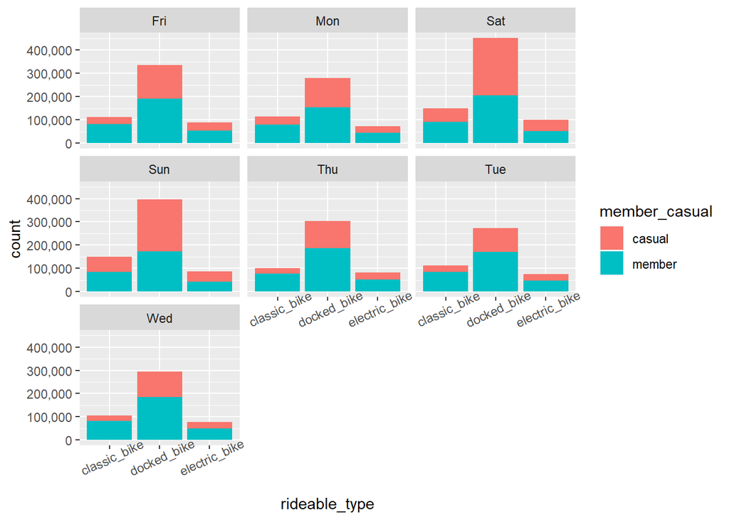

```r
ggplot(df, aes(rideable_type, fill=member_casual))+
  geom_bar()+
  scale_y_continuous(labels=comma)+
  facet_wrap(~weekday)+
  theme(axis.text.x = element_text(angle=25))
```

**f) Let’s consider riding_time feature now** Let’s print the summary of the riding_time variable to check if there are any anomalies.

```r
summary(df$riding_time)
```

```
##      Min.   1st Qu.    Median      Mean   3rd Qu.      Max.
## -29049.97      7.82     14.22     24.63     26.15  54283.35
```

As can be seen, there are outliers. The minimum riding time is negative, which is unusual as time can’t be negative. The maximum also seems too large (that is, the rider has taken the bike for approximately 37 days). To confirm that this is an outlier, let’s check each quantile value.

Printing the values in each quantiles with 5% difference

```r
quantiles <- quantile(df$riding_time, seq(0,1,by=0.05))
quantiles
```

```
##            0%            5%           10%           15%           20%
## -29049.966667      3.150000      4.550000      5.683333      6.750000
##           25%           30%           35%           40%           45%
##      7.816667      8.933333     10.100000     11.350000     12.700000
##           50%           55%           60%           65%           70%
##     14.216667     15.933333     17.900000     20.183333     22.900000
##           75%           80%           85%           90%           95%
##     26.150000     30.133333     35.950000     45.650000     72.016667
##          100%
##  54283.350000
```

It is clear that the maximum value was an outlier and hence it is unworthy of consideration.

Considering only the values in the 5-95% interval

```r
new_df_without_outliers <- df %>%
  filter(riding_time > as.numeric(quantiles['5%'])) %>%
  filter(riding_time < as.numeric(quantiles['95%']))

final_df <- new_df_without_outliers
```

Now let’s compare the riding_time with all the other features used before

**g) Let’s start by checking the riding time of both members and casual riders**

```r
final_df %>%
  group_by(member_casual) %>%
  summarize(mean=mean(riding_time),
            first_quarter=quantile(riding_time, 0.25),
            median=median(riding_time),
            third_quarter=quantile(riding_time, 0.75),
            IQR = third_quarter-first_quarter)
```

```
## # A tibble: 2 x 6
##   member_casual  mean first_quarter median third_quarter   IQR
##   <chr>         <dbl>         <dbl>  <dbl>         <dbl> <dbl>
## 1 casual         23.3          11.1   18.8          31    19.9
## 2 member         15.1           7.2   11.9          20.0  12.8
```

Let’s plot the same and check for any trends.

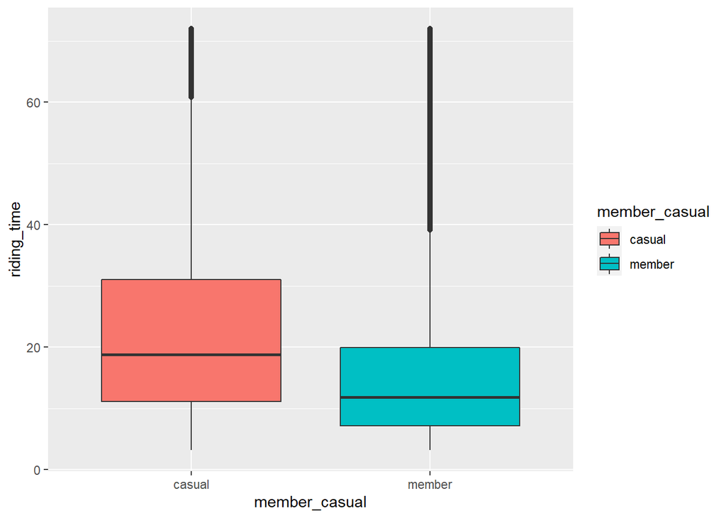

```r
ggplot(final_df, aes(x=member_casual, y=riding_time, fill=member_casual))+
  geom_boxplot()
```

**h) Let’s next check riding time of both members and casual riders for each of the week** Since the riding time is continuous and any feature compared to it would be discrete, we can go with box plots.

```r
final_df %>%
  group_by(weekday) %>%
  summarize(mean=mean(riding_time),
            first_quarter=quantile(riding_time, 0.25),
            median=median(riding_time),
            third_quarter=quantile(riding_time, 0.75),
            IQR = third_quarter-first_quarter)
```

```
## # A tibble: 7 x 6
##   weekday  mean first_quarter median third_quarter   IQR
##   <chr>   <dbl>         <dbl>  <dbl>         <dbl> <dbl>
## 1 Fri      17.5          8.05   13.4          22.9  14.9
## 2 Mon      18.3          8.07   13.9          24.4  16.3
## 3 Sat      20.2          9.47   16.1          26.9  17.5
## 4 Sun      20.9          9.65   16.7          28.0  18.4
## 5 Thu      16.9          7.77   12.9          22.0  14.3
## 6 Tue      17.1          7.75   13.0          22.5  14.7
## 7 Wed      16.8          7.73   12.9          22.0  14.2
```

Let’s plot the same and check for any trends.

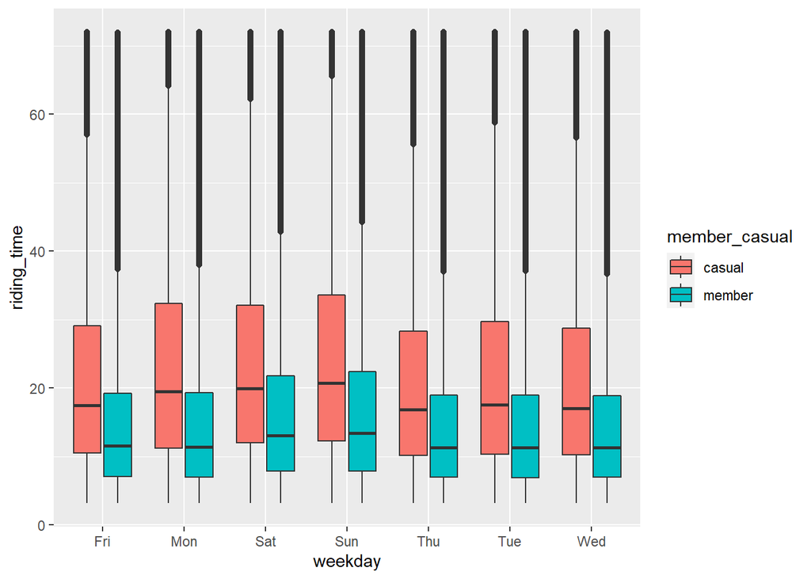

```r
ggplot(final_df, aes(x=weekday, y=riding_time, fill=member_casual))+
  geom_boxplot()
```

It can be clearly seen that the casual riders spend more time riding than annual members. Let’s see why this is the case in the next steps.

**i) Let’s now check how these times vary for each month**

```r
final_df %>%
  group_by(year_month) %>%
  summarize(mean=mean(riding_time),
            first_quarter=quantile(riding_time, 0.25),
            median=median(riding_time),
            third_quarter=quantile(riding_time, 0.75),
            IQR = third_quarter-first_quarter)
```

```
## # A tibble: 13 x 6
##    year_month       mean first_quarter median third_quarter   IQR
##    <chr>           <dbl>         <dbl>  <dbl>         <dbl> <dbl>
##  1 2020 - 06 - Jun  21.0         10.4    17.4          27.9  17.6
##  2 2020 - 07 - Jul  21.0         10.0    17.0          27.9  17.8
##  3 2020 - 08 - Aug  19.7          9.3    15.7          26.3  17.0
##  4 2020 - 09 - Sep  18.2          8.37   14.1          24.0  15.7
##  5 2020 - 10 - Oct  16.2          7.4    12.2          21.0  13.6
##  6 2020 - 11 - Nov  16.2          7.15   12.0          21.0  13.9
##  7 2020 - 12 - Dec  13.9          6.5    10.4          17.8  11.2
##  8 2021 - 01 - Jan  13.2          6.3     9.9          16.7  10.4
##  9 2021 - 02 - Feb  15.3          7.18   11.5          19.5  12.4
## 10 2021 - 03 - Mar  17.1          7.55   12.8          22.5  14.9
## 11 2021 - 04 - Apr  17.4          7.8    13.1          22.8  15.0
## 12 2021 - 05 - May  18.3          8.28   14.0          24.2  15.9
## 13 2021 - 06 - Jun  20.3          8.87   15.9          27.4  18.5
```

Let’s plot the same and check for any trends.

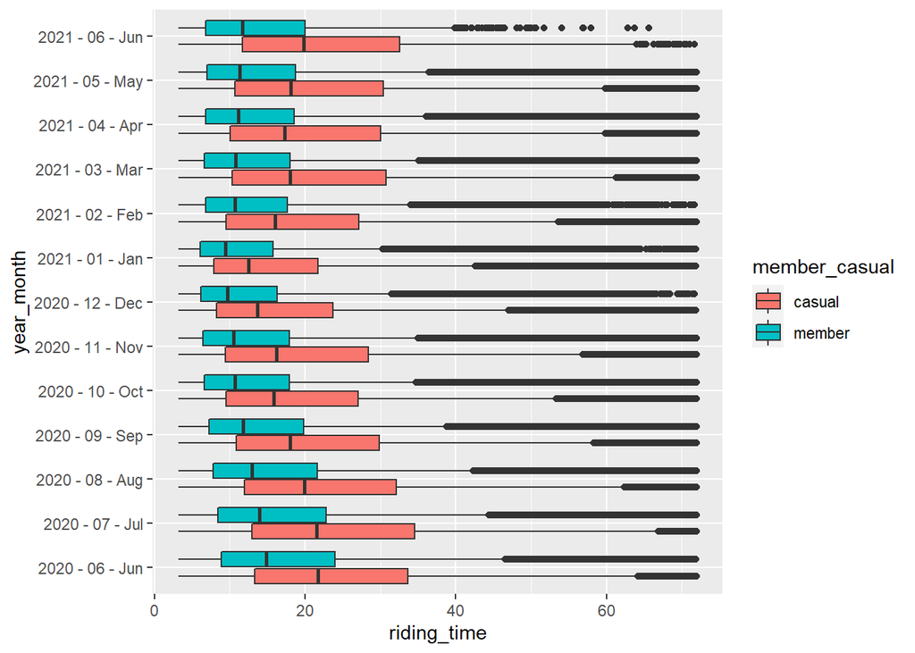

```r
ggplot(final_df, aes(x=year_month, y=riding_time, fill=member_casual))+
  geom_boxplot()+
  coord_flip()
```

As the number of riders in the winter months was less, the same reflects in the riding time.

# Observations

**Annual Members vs Casual Riders**

**Changes required to convert casual riders to annual members:**

1. Impose offers for annual members and not for casual riders.
2. Increase the price of the bikes on weekends for casual riders.
3. Place special offers for anyone who registers for the annual membership from November to February.
4. Reduce the limit on the time duration or distance a casual rider can travel.

5)Increase the surge for bikes for casual riders in the evenings. Annual members riding the bikes in the mid-night can avail themselves of free cafe or bar coupons.